# MovieLens Project

### Project - MovieLens Data Analysis

The GroupLens Research Project is a research group in the Department of Computer Science and Engineering at the University of Minnesota. The data is widely used for collaborative filtering and other filtering solutions. However, we will be using this data to act as a means to demonstrate our skill in using Python to “play” with data.

#### Domain

Internet and Entertainment

**Note that the project will need you to apply the concepts of groupby and merging extensively.**

#### 1. Import the necessary packages - 2.5 marks

```python
import numpy as np
import pandas as pd
import matplotlib.pyplot as plt
import seaborn as sns

pd.set_option('display.max_columns', None)  # Show all columns
pd.set_option('display.expand_frame_repr', False)  # Disable column wrapping
```

#### 2. Read the 3 datasets into dataframes - 2.5 marks

```python
UsersRating = pd.read_csv('Data.csv');
Movies = pd.read_csv('item.csv');
Users = pd.read_csv('user.csv');
```

```python
Movies.head(5)
```

|  | movie id | movie title | release date | unknown | Action | Adventure | Animation | Childrens | Comedy | Crime | Documentary | Drama | Fantasy | Film-Noir | Horror | Musical | Mystery | Romance | Sci-Fi | Thriller | War | Western |
| --- | --- | --- | --- | --- | --- | --- | --- | --- | --- | --- | --- | --- | --- | --- | --- | --- | --- | --- | --- | --- | --- | --- |
| 0 | 1 | Toy Story | 01-Jan-1995 | 0 | 0 | 0 | 1 | 1 | 1 | 0 | 0 | 0 | 0 | 0 | 0 | 0 | 0 | 0 | 0 | 0 | 0 | 0 |
| 1 | 2 | GoldenEye | 01-Jan-1995 | 0 | 1 | 1 | 0 | 0 | 0 | 0 | 0 | 0 | 0 | 0 | 0 | 0 | 0 | 0 | 0 | 1 | 0 | 0 |
| 2 | 3 | Four Rooms | 01-Jan-1995 | 0 | 0 | 0 | 0 | 0 | 0 | 0 | 0 | 0 | 0 | 0 | 0 | 0 | 0 | 0 | 0 | 1 | 0 | 0 |
| 3 | 4 | Get Shorty | 01-Jan-1995 | 0 | 1 | 0 | 0 | 0 | 1 | 0 | 0 | 1 | 0 | 0 | 0 | 0 | 0 | 0 | 0 | 0 | 0 | 0 |
| 4 | 5 | Copycat | 01-Jan-1995 | 0 | 0 | 0 | 0 | 0 | 0 | 1 | 0 | 1 | 0 | 0 | 0 | 0 | 0 | 0 | 0 | 1 | 0 | 0 |

```python
Users.head(5)
```

|  | user id | age | gender | occupation | zip code |
| --- | --- | --- | --- | --- | --- |
| 0 | 1 | 24 | M | technician | 85711 |
| 1 | 2 | 53 | F | other | 94043 |
| 2 | 3 | 23 | M | writer | 32067 |
| 3 | 4 | 24 | M | technician | 43537 |
| 4 | 5 | 33 | F | other | 15213 |

```python
UsersRating.head(5)
```

|  | user id | movie id | rating | timestamp |
| --- | --- | --- | --- | --- |
| 0 | 196 | 242 | 3 | 881250949 |
| 1 | 186 | 302 | 3 | 891717742 |
| 2 | 22 | 377 | 1 | 878887116 |
| 3 | 244 | 51 | 2 | 880606923 |
| 4 | 166 | 346 | 1 | 886397596 |

#### 3. Apply info, shape, describe, and find the number of missing values in the data - 5 marks

```python
print("Movies shape: ")
print(Movies.shape)
print("\nUsers shape: ")
print(Users.shape)
print("\nRating shape: ")
print(UsersRating.shape)

print("\n\nMovie info")
print(Movies.info())
print("\n\nUser info")
print(Users.info())
print("\n\nRating info")
print(UsersRating.info())

print("\n\nMovie describe")
print(Movies.describe())
print("\n\nUser describe")
print(Users.describe())
print("\n\nRating describe")
print(UsersRating.describe())
```

```
Movies shape:
(1681, 22)

Users shape:
(943, 5)

Rating shape:
(100000, 4)


Movie info
<class 'pandas.core.frame.DataFrame'>
RangeIndex: 1681 entries, 0 to 1680
Data columns (total 22 columns):
 #   Column        Non-Null Count  Dtype
---  ------        --------------  -----
 0   movie id      1681 non-null   int64
 1   movie title   1681 non-null   object
 2   release date  1681 non-null   object
 3   unknown       1681 non-null   int64
 4   Action        1681 non-null   int64
 5   Adventure     1681 non-null   int64
 6   Animation     1681 non-null   int64
 7   Childrens     1681 non-null   int64
 8   Comedy        1681 non-null   int64
 9   Crime         1681 non-null   int64
 10  Documentary   1681 non-null   int64
 11  Drama         1681 non-null   int64
 12  Fantasy       1681 non-null   int64
 13  Film-Noir     1681 non-null   int64
 14  Horror        1681 non-null   int64
 15  Musical       1681 non-null   int64
 16  Mystery       1681 non-null   int64
 17  Romance       1681 non-null   int64
 18  Sci-Fi        1681 non-null   int64
 19  Thriller      1681 non-null   int64
 20  War           1681 non-null   int64
 21  Western       1681 non-null   int64
dtypes: int64(20), object(2)
memory usage: 289.1+ KB
```

[output cut: 53 more lines]

```
50%    472.000000   31.000000
75%    707.500000   43.000000
max    943.000000   73.000000


Rating describe
            user id       movie id         rating     timestamp
count  100000.00000  100000.000000  100000.000000  1.000000e+05
mean      462.48475     425.530130       3.529860  8.835289e+08
std       266.61442     330.798356       1.125674  5.343856e+06
min         1.00000       1.000000       1.000000  8.747247e+08
25%       254.00000     175.000000       3.000000  8.794487e+08
50%       447.00000     322.000000       4.000000  8.828269e+08
75%       682.00000     631.000000       4.000000  8.882600e+08
max       943.00000    1682.000000       5.000000  8.932866e+08
```

#### 4. Find the number of movies per genre using the item data - 5 marks

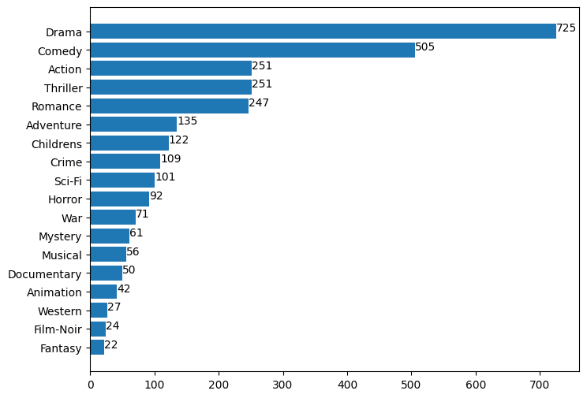

```python
MoviesGenre = Movies.drop(['movie id', 'movie title', 'release date', 'unknown'], axis=1).sum().sort_values()
mx = MoviesGenre.index
my = MoviesGenre.values

plt.rcParams["figure.figsize"] = (8, 6)
plt.barh(mx, my)

for index, value in enumerate(my):
    plt.text(value, index, str(value))
```

#### 5. Find the movies that have more than one genre - 2.5 marks

```python
Movies['genre count'] = Movies.loc[:,'Action':'Western'].sum(axis=1)
print("Movies with more than 1 genre: " + str(len(Movies.loc[Movies['genre count'] > 1])))
```

```
Movies with more than 1 genre: 849
```

#### 6. Drop the movie where the genre is unknown - 2.5 marks

```python
Movies = Movies.drop(Movies.loc[(Movies['unknown'] == 1) & (Movies.loc[:, 'Action':'Western'].sum(axis=1) == 0)].index)
Movies = Movies.drop('unknown', axis=1)
Movies.head()
```

|  | movie id | movie title | release date | Action | Adventure | Animation | Childrens | Comedy | Crime | Documentary | Drama | Fantasy | Film-Noir | Horror | Musical | Mystery | Romance | Sci-Fi | Thriller | War | Western | genre count |
| --- | --- | --- | --- | --- | --- | --- | --- | --- | --- | --- | --- | --- | --- | --- | --- | --- | --- | --- | --- | --- | --- | --- |
| 0 | 1 | Toy Story | 01-Jan-1995 | 0 | 0 | 1 | 1 | 1 | 0 | 0 | 0 | 0 | 0 | 0 | 0 | 0 | 0 | 0 | 0 | 0 | 0 | 3 |
| 1 | 2 | GoldenEye | 01-Jan-1995 | 1 | 1 | 0 | 0 | 0 | 0 | 0 | 0 | 0 | 0 | 0 | 0 | 0 | 0 | 0 | 1 | 0 | 0 | 3 |
| 2 | 3 | Four Rooms | 01-Jan-1995 | 0 | 0 | 0 | 0 | 0 | 0 | 0 | 0 | 0 | 0 | 0 | 0 | 0 | 0 | 0 | 1 | 0 | 0 | 1 |
| 3 | 4 | Get Shorty | 01-Jan-1995 | 1 | 0 | 0 | 0 | 1 | 0 | 0 | 1 | 0 | 0 | 0 | 0 | 0 | 0 | 0 | 0 | 0 | 0 | 3 |
| 4 | 5 | Copycat | 01-Jan-1995 | 0 | 0 | 0 | 0 | 0 | 1 | 0 | 1 | 0 | 0 | 0 | 0 | 0 | 0 | 0 | 1 | 0 | 0 | 3 |

```python
# HINT: use distplot for age and countplot for gender,ratings,occupation.
# HINT: Please refer to the below snippet to understand how to get to release year from release date. You can use str.split()
# as depicted below
# Hint : Use displot without kde for release year or line plot showing year wise count.
```

```python
a = 'My*cat*is*brown'
print(a.split('*')[3])

#similarly, the release year needs to be taken out from release date

#also you can simply slice existing string to get the desired data, if we want to take out the colour of the cat

print(a[10:])
print(a[-5:])
```

```
brown
brown
brown
```

```python
Movies['release date'] = pd.to_datetime(Movies['release date'])
Movies['release year'] = Movies['release date'].dt.year
Movies.head()
```

|  | movie id | movie title | release date | Action | Adventure | Animation | Childrens | Comedy | Crime | Documentary | Drama | Fantasy | Film-Noir | Horror | Musical | Mystery | Romance | Sci-Fi | Thriller | War | Western | genre count | release year |
| --- | --- | --- | --- | --- | --- | --- | --- | --- | --- | --- | --- | --- | --- | --- | --- | --- | --- | --- | --- | --- | --- | --- | --- |
| 0 | 1 | Toy Story | 1995-01-01 | 0 | 0 | 1 | 1 | 1 | 0 | 0 | 0 | 0 | 0 | 0 | 0 | 0 | 0 | 0 | 0 | 0 | 0 | 3 | 1995 |
| 1 | 2 | GoldenEye | 1995-01-01 | 1 | 1 | 0 | 0 | 0 | 0 | 0 | 0 | 0 | 0 | 0 | 0 | 0 | 0 | 0 | 1 | 0 | 0 | 3 | 1995 |
| 2 | 3 | Four Rooms | 1995-01-01 | 0 | 0 | 0 | 0 | 0 | 0 | 0 | 0 | 0 | 0 | 0 | 0 | 0 | 0 | 0 | 1 | 0 | 0 | 1 | 1995 |
| 3 | 4 | Get Shorty | 1995-01-01 | 1 | 0 | 0 | 0 | 1 | 0 | 0 | 1 | 0 | 0 | 0 | 0 | 0 | 0 | 0 | 0 | 0 | 0 | 3 | 1995 |
| 4 | 5 | Copycat | 1995-01-01 | 0 | 0 | 0 | 0 | 0 | 1 | 0 | 1 | 0 | 0 | 0 | 0 | 0 | 0 | 0 | 1 | 0 | 0 | 3 | 1995 |

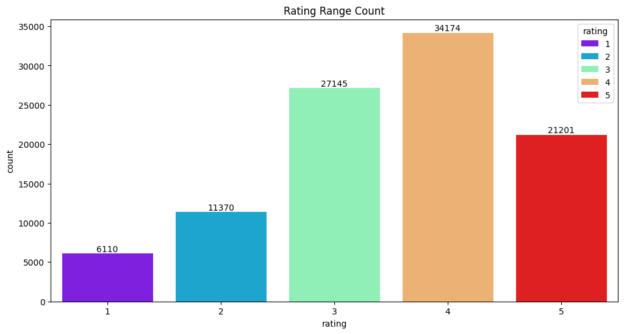

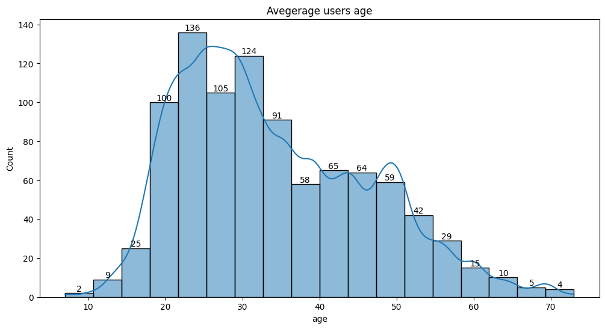

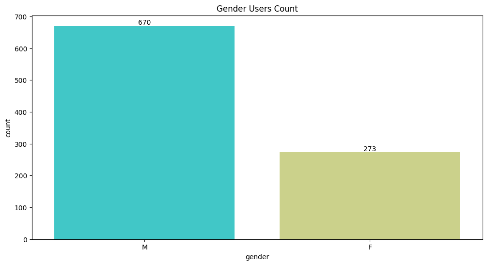

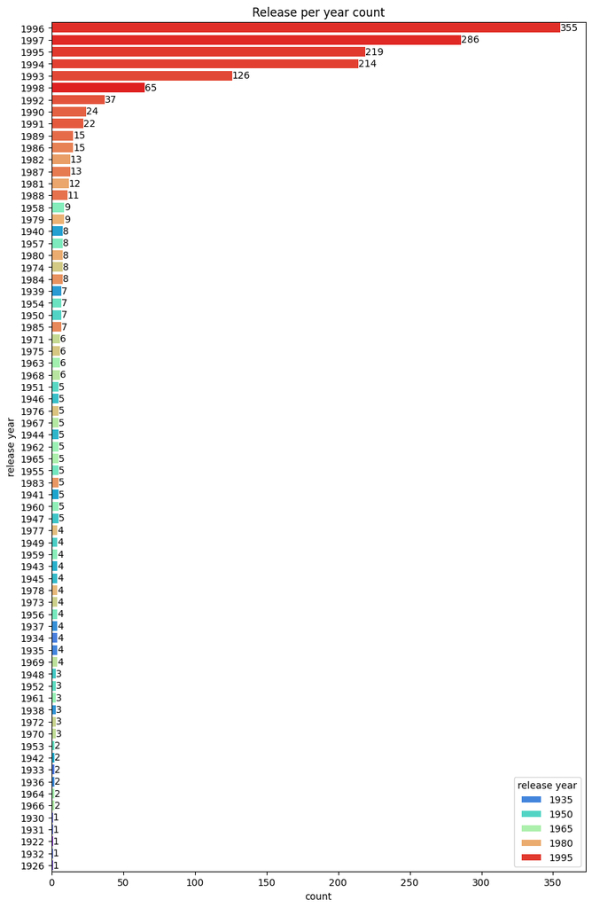

```python
plt.rcParams["figure.figsize"] = (12,6)

#Rating

ratingP = sns.countplot(x='rating', data=UsersRating, palette='rainbow', hue='rating')
for container in ratingP.containers:
    ratingP.bar_label(container)

plt.title("Rating Range Count")
plt.show()

#Age
ageP = sns.histplot(Users['age'], kde=True, kde_kws={'bw_adjust': 0.4})
for container in ageP.containers:
    ageP.bar_label(container)

plt.title("Avegerage users age")
plt.show()

#Gender
genderP = sns.countplot(x='gender', data=Users, palette='rainbow', hue='gender')
for container in genderP.containers:
    genderP.bar_label(container)

plt.title("Gender Users Count")
plt.show()

#Release Year
plt.rcParams["figure.figsize"] = (10,16)

releaseP = sns.countplot(y = 'release year', data=Movies, order=Movies['release year'].value_counts().index, orient='h', palette='rainbow', hue='release year')
for container in releaseP.containers:
    releaseP.bar_label(container)

plt.title("Release per year count")
plt.show()

#Reset Matplot
plt.rcdefaults()
```

### 8. Visualize how popularity of genres has changed over the years - 10 marks

Note that you need to use the number of releases in a year as a parameter of popularity of a genre

Hint

1: you need to reach to a data frame where the release year is the index and the genre is the column names (one cell shows the number of release in a year in one genre) or vice versa. Once that is achieved, you can either use univariate plots or can use the heatmap to visualise all the changes over the years in one go.

Hint 2: Use groupby on the relevant column and use sum() on the same to find out the nuumber of releases in a year/genre.

```python
maxCount = 0
listPopularity = []

for genre in MoviesGenre.index:
    ToPrint = maxCount == 0

    Popularity = pd.DataFrame(Movies, columns=['release year', genre])
    if ToPrint:
        print("Initial DataFrame for genre:", genre)
        print(Popularity.head())

    Popularity = Popularity.loc[Movies[genre] != 0].sort_values('release year')
    if ToPrint:
        print("\nAfter filtering and sorting for genre:", genre)
        print(Popularity.head())

    Popularity = Popularity.groupby('release year').count().agg(list).T
    if ToPrint:
        print("\nAfter grouping and counting for genre:", genre)
        print(Popularity.head(10))

    listPopularity.append(Popularity)

    maxGenre = Popularity.max().max()
    if maxCount < maxGenre:
        maxCount = maxGenre
```

```
Initial DataFrame for genre: Fantasy
   release year  Fantasy
0          1995        0
1          1995        0
2          1995        0
3          1995        0
4          1995        0

After filtering and sorting for genre: Fantasy
      release year  Fantasy
140           1954        1
1131          1975        1
421           1982        1
1574          1987        1
1034          1991        1

After grouping and counting for genre: Fantasy
release year  1954  1975  1982  1987  1991  1994  1995  1996  1997  1998
Fantasy          1     1     1     1     1     3     3     6     4     1
```

```python
PopularityFrame = pd.concat(listPopularity)
PopularityFrame = PopularityFrame.fillna(0).sort_index(axis=1)

PopularityFrame.head()
```

| release year | 1922 | 1926 | 1930 | 1931 | 1932 | 1933 | 1934 | 1935 | 1936 | 1937 | 1938 | 1939 | 1940 | 1941 | 1942 | 1943 | 1944 | 1945 | 1946 | 1947 | 1948 | 1949 | 1950 | 1951 | 1952 | 1953 | 1954 | 1955 | 1956 | … |
| --- | --- | --- | --- | --- | --- | --- | --- | --- | --- | --- | --- | --- | --- | --- | --- | --- | --- | --- | --- | --- | --- | --- | --- | --- | --- | --- | --- | --- | --- | --- |
| Fantasy | 0.0 | 0.0 | 0.0 | 0.0 | 0.0 | 0.0 | 0.0 | 0.0 | 0.0 | 0.0 | 0.0 | 0.0 | 0.0 | 0.0 | 0.0 | 0.0 | 0.0 | 0.0 | 0.0 | 0.0 | 0.0 | 0.0 | 0.0 | 0.0 | 0.0 | 0.0 | 1.0 | 0.0 | 0.0 | … |
| Film-Noir | 0.0 | 0.0 | 0.0 | 1.0 | 0.0 | 0.0 | 0.0 | 0.0 | 0.0 | 0.0 | 0.0 | 0.0 | 0.0 | 1.0 | 0.0 | 0.0 | 2.0 | 0.0 | 2.0 | 2.0 | 2.0 | 0.0 | 1.0 | 0.0 | 0.0 | 0.0 | 0.0 | 0.0 | 0.0 | … |
| Western | 0.0 | 0.0 | 0.0 | 0.0 | 0.0 | 0.0 | 0.0 | 0.0 | 0.0 | 0.0 | 0.0 | 0.0 | 0.0 | 0.0 | 0.0 | 1.0 | 0.0 | 0.0 | 0.0 | 1.0 | 0.0 | 0.0 | 0.0 | 0.0 | 1.0 | 0.0 | 1.0 | 1.0 | 0.0 | … |
| Animation | 0.0 | 0.0 | 0.0 | 0.0 | 0.0 | 0.0 | 0.0 | 0.0 | 0.0 | 1.0 | 0.0 | 0.0 | 2.0 | 1.0 | 0.0 | 0.0 | 0.0 | 1.0 | 0.0 | 0.0 | 0.0 | 0.0 | 1.0 | 1.0 | 0.0 | 0.0 | 0.0 | 0.0 | 0.0 | … |
| Documentary | 0.0 | 0.0 | 0.0 | 0.0 | 0.0 | 0.0 | 0.0 | 0.0 | 0.0 | 0.0 | 0.0 | 0.0 | 0.0 | 0.0 | 0.0 | 0.0 | 0.0 | 0.0 | 0.0 | 0.0 | 0.0 | 0.0 | 0.0 | 0.0 | 0.0 | 0.0 | 0.0 | 0.0 | 0.0 | … |

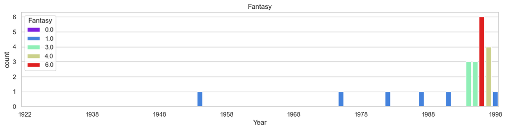

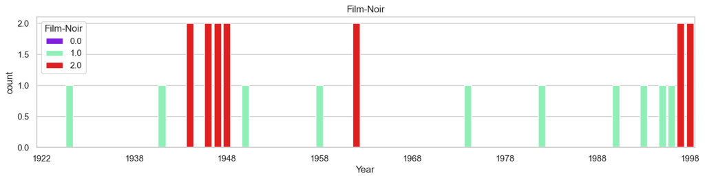

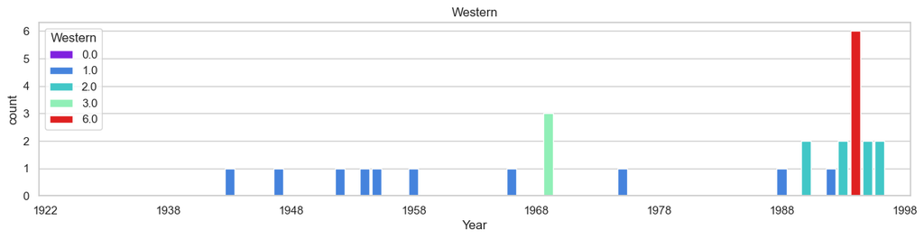

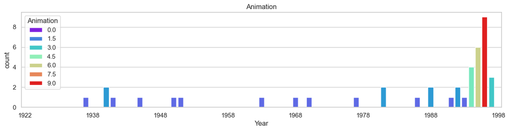

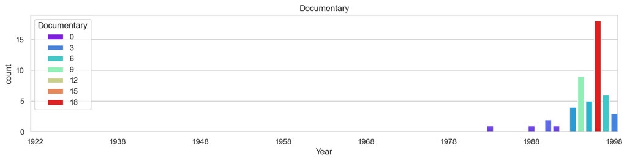

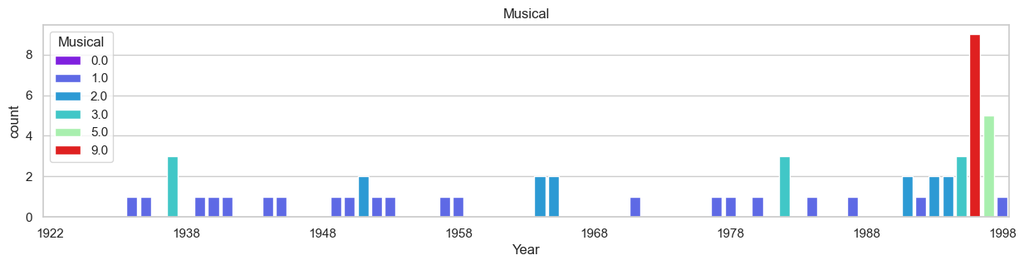

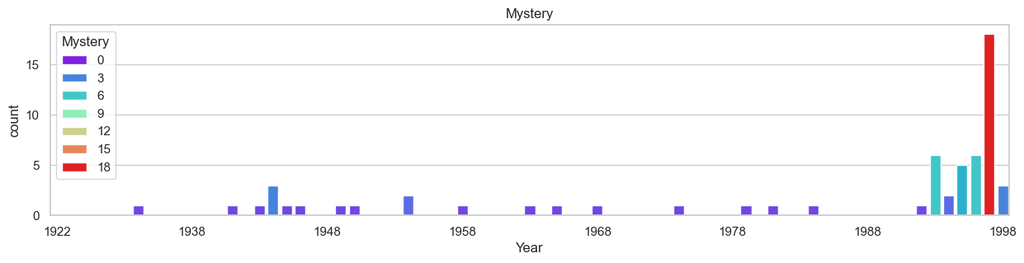

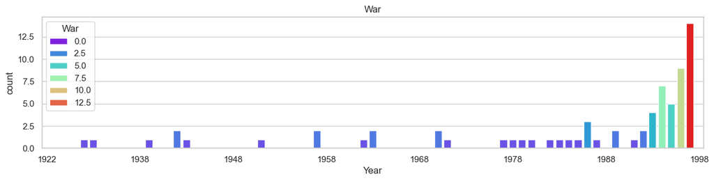

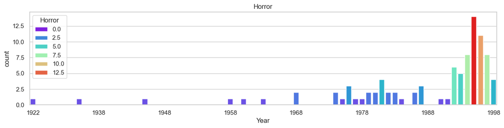

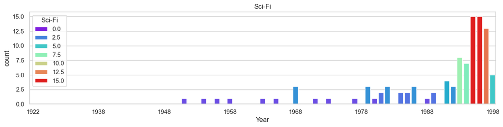

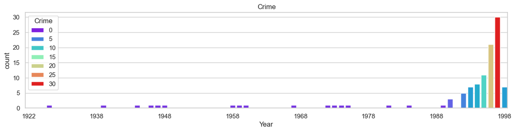

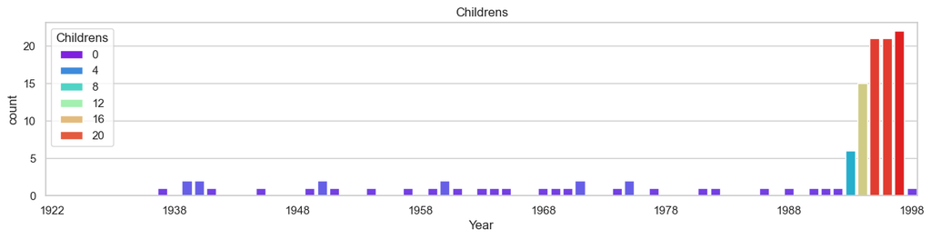

[6 more figures not shown]

```python
sns.set_theme(style="whitegrid")
plt.rcParams["figure.figsize"] = (15,3)
for genre in MoviesGenre.index:
    Popularity = pd.DataFrame(PopularityFrame.T, columns=[genre])

    currentG = sns.barplot(x=Popularity.index, y=genre, data=Popularity, palette='rainbow', hue=genre)
    for ind, label in enumerate(currentG.get_xticklabels()):
        if ind % 10 == 0:  # every 10th label is kept
            label.set_visible(True)
        else:
            label.set_visible(False)

    plt.ylim(bottom=0)
    plt.xlabel('Year')
    plt.ylabel('count')
    plt.title(genre)
    plt.show()

plt.rcdefaults()
```

### 9. Find the top 25 movies according to average ratings such that each movie has number of ratings more than 100 - 10 marks

Hint :

1. First find the movies that have more than 100 ratings(use merge, groupby and count). Extract the movie titles in a list.
2. Find the average rating of all the movies and sort them in the descending order. You will have to use the .merge() function to reach to a data set through which you can get the names and the average rating.
3. Use isin(list obtained from 1) to filter out the movies which have more than 100 ratings.

Note: This question will need you to research about groupby and apply your findings. You can find more on groupby on https://realpython.com/pandas-groupby/.

```python
# User Rating X Movie Frame
OneForAllMR = pd.merge(left=Movies, right=UsersRating , on="movie id",  how='left')
MoviesRating = pd.DataFrame(OneForAllMR, columns=['movie title', 'rating'])

# Counting votes by movie
MoviesRatingC = MoviesRating.groupby('movie title', as_index=False).count().agg(list)

# Filtering by the amount of votes
MoviesRatingC = MoviesRatingC.loc[MoviesRatingC['rating']>100]
MoviesRatingC.head()
```

|  | movie title | rating |
| --- | --- | --- |
| 2 | 101 Dalmatians | 109 |
| 3 | 12 Angry Men | 125 |
| 7 | 2001: A Space Odyssey | 259 |
| 15 | Absolute Power | 127 |
| 16 | Abyss, The | 151 |

```python
# Calculating mean rate by movie title
MoviesRatingG = MoviesRating.groupby('movie title', as_index=False).mean().agg(list)
MoviesRatingG = MoviesRatingG.loc[MoviesRatingC.index].sort_values(by='rating', ascending=False).head(25)
MoviesRatingG.head()
```

|  | movie title | rating |
| --- | --- | --- |
| 317 | Close Shave, A | 4.491071 |
| 1277 | Schindler's List | 4.466443 |
| 1646 | Wrong Trousers, The | 4.466102 |
| 272 | Casablanca | 4.456790 |
| 1312 | Shawshank Redemption, The | 4.445230 |

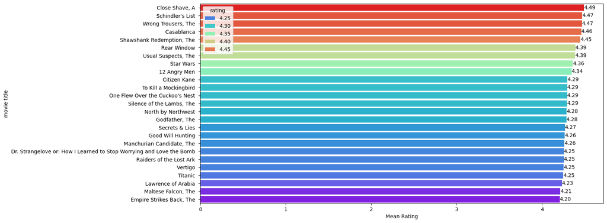

```python
plt.rcParams["figure.figsize"] = (14,7)

bestRating = sns.barplot(y = 'movie title', x='rating', data=MoviesRatingG, orient='h', palette='rainbow', hue='rating')
for container in bestRating.containers:
    bestRating.bar_label(container, fmt="{:.2f}")

plt.xlabel('Mean Rating')

plt.show()
```

### 10. See gender distribution across different genres check for the validity of the below statements - 10 marks

- Men watch more drama than women
- Women watch more Sci-Fi than men
- Men watch more Romance than women
1. There is no need to conduct statistical tests around this. Just compare the percentages and comment on the validity of the above statements.
2. you might want ot use the .sum(), .div() function here.
3. Use number of ratings to validate the numbers. For example, if out of 4000 ratings received by women, 3000 are for drama, we will assume that 75% of the women watch drama.

```python
# Full merge between Movie X Rate X User
OneForAllUS = pd.merge(left=OneForAllMR, right=Users , on="user id",  how='left')
OneForAllUS.head()
```

|  | movie id | movie title | release date | Action | Adventure | Animation | Childrens | Comedy | Crime | Documentary | Drama | Fantasy | Film-Noir | Horror | Musical | Mystery | Romance | Sci-Fi | Thriller | War | Western | genre count | release year | user id | rating | timestamp | age | gender | occupation | … |
| --- | --- | --- | --- | --- | --- | --- | --- | --- | --- | --- | --- | --- | --- | --- | --- | --- | --- | --- | --- | --- | --- | --- | --- | --- | --- | --- | --- | --- | --- | --- |
| 0 | 1 | Toy Story | 1995-01-01 | 0 | 0 | 1 | 1 | 1 | 0 | 0 | 0 | 0 | 0 | 0 | 0 | 0 | 0 | 0 | 0 | 0 | 0 | 3 | 1995 | 308 | 4 | 887736532 | 60 | M | retired | … |
| 1 | 1 | Toy Story | 1995-01-01 | 0 | 0 | 1 | 1 | 1 | 0 | 0 | 0 | 0 | 0 | 0 | 0 | 0 | 0 | 0 | 0 | 0 | 0 | 3 | 1995 | 287 | 5 | 875334088 | 21 | M | salesman | … |
| 2 | 1 | Toy Story | 1995-01-01 | 0 | 0 | 1 | 1 | 1 | 0 | 0 | 0 | 0 | 0 | 0 | 0 | 0 | 0 | 0 | 0 | 0 | 0 | 3 | 1995 | 148 | 4 | 877019411 | 33 | M | engineer | … |
| 3 | 1 | Toy Story | 1995-01-01 | 0 | 0 | 1 | 1 | 1 | 0 | 0 | 0 | 0 | 0 | 0 | 0 | 0 | 0 | 0 | 0 | 0 | 0 | 3 | 1995 | 280 | 4 | 891700426 | 30 | F | librarian | … |
| 4 | 1 | Toy Story | 1995-01-01 | 0 | 0 | 1 | 1 | 1 | 0 | 0 | 0 | 0 | 0 | 0 | 0 | 0 | 0 | 0 | 0 | 0 | 0 | 3 | 1995 | 66 | 3 | 883601324 | 23 | M | student | … |

### 10.1 Female Data

```python
FemaleDistribution = OneForAllUS.loc[(OneForAllUS['gender'] == 'F')]
FemaleDistribution.head()
```

|  | movie id | movie title | release date | Action | Adventure | Animation | Childrens | Comedy | Crime | Documentary | Drama | Fantasy | Film-Noir | Horror | Musical | Mystery | Romance | Sci-Fi | Thriller | War | Western | genre count | release year | user id | rating | timestamp | age | gender | occupation | … |
| --- | --- | --- | --- | --- | --- | --- | --- | --- | --- | --- | --- | --- | --- | --- | --- | --- | --- | --- | --- | --- | --- | --- | --- | --- | --- | --- | --- | --- | --- | --- |
| 3 | 1 | Toy Story | 1995-01-01 | 0 | 0 | 1 | 1 | 1 | 0 | 0 | 0 | 0 | 0 | 0 | 0 | 0 | 0 | 0 | 0 | 0 | 0 | 3 | 1995 | 280 | 4 | 891700426 | 30 | F | librarian | … |
| 5 | 1 | Toy Story | 1995-01-01 | 0 | 0 | 1 | 1 | 1 | 0 | 0 | 0 | 0 | 0 | 0 | 0 | 0 | 0 | 0 | 0 | 0 | 0 | 3 | 1995 | 5 | 4 | 875635748 | 33 | F | other | … |
| 15 | 1 | Toy Story | 1995-01-01 | 0 | 0 | 1 | 1 | 1 | 0 | 0 | 0 | 0 | 0 | 0 | 0 | 0 | 0 | 0 | 0 | 0 | 0 | 3 | 1995 | 150 | 4 | 878746441 | 20 | F | artist | … |
| 18 | 1 | Toy Story | 1995-01-01 | 0 | 0 | 1 | 1 | 1 | 0 | 0 | 0 | 0 | 0 | 0 | 0 | 0 | 0 | 0 | 0 | 0 | 0 | 3 | 1995 | 49 | 2 | 888068651 | 23 | F | student | … |
| 19 | 1 | Toy Story | 1995-01-01 | 0 | 0 | 1 | 1 | 1 | 0 | 0 | 0 | 0 | 0 | 0 | 0 | 0 | 0 | 0 | 0 | 0 | 0 | 3 | 1995 | 223 | 4 | 891549324 | 19 | F | student | … |

```python
FemaleCount = {}
FemaleTotal = FemaleDistribution.drop_duplicates(subset=['movie id', 'user id']).index.size
print("Unique female votes: " + str(FemaleTotal))

# Calculate the count and percentage for each genre
for genre in MoviesGenre.index:
    genre_sum = FemaleDistribution[genre].sum()
    percentage = (genre_sum / FemaleTotal) * 100
    FemaleCount[genre] = [genre_sum, percentage]

# Convert the dictionary to a DataFrame
FemalePopularity = pd.DataFrame.from_dict(FemaleCount, orient='index', columns=['Count', 'Percentage']).sort_values(by='Percentage', ascending=False)

# Print the DataFrame
print(FemalePopularity)
```

```
Unique female votes: 25738
             Count  Percentage
Drama        11008   42.769446
Comedy        8068   31.346647
Romance       5858   22.760121
Action        5442   21.143834
Thriller      5086   19.760665
Adventure     3141   12.203745
Sci-Fi        2629   10.214469
Childrens     2232    8.672002
War           2189    8.504934
Crime         1794    6.970239
Musical       1442    5.602611
Mystery       1314    5.105292
Horror        1197    4.650711
Animation      995    3.865879
Film-Noir      385    1.495843
Western        371    1.441448
Fantasy        363    1.410366
Documentary    187    0.726552
```

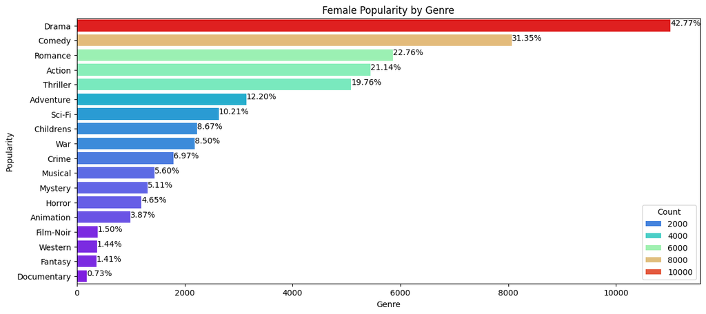

```python
plt.figure(figsize=(14, 6))

sns.barplot(y=FemalePopularity.index, x='Count', data=FemalePopularity, palette='rainbow', hue='Count')

for index, value in enumerate(FemalePopularity['Count']):
    plt.text(value, index, f"{FemalePopularity['Percentage'].iloc[index]:.2f}%")

plt.title('Female Popularity by Genre')
plt.xlabel('Genre')
plt.ylabel('Popularity')
plt.show()
```

### 10.2 Male Data

```python
MaleDistribution = OneForAllUS.loc[(OneForAllUS['gender'] == 'M')]
MaleDistribution.head()
```

|  | movie id | movie title | release date | Action | Adventure | Animation | Childrens | Comedy | Crime | Documentary | Drama | Fantasy | Film-Noir | Horror | Musical | Mystery | Romance | Sci-Fi | Thriller | War | Western | genre count | release year | user id | rating | timestamp | age | gender | occupation | … |
| --- | --- | --- | --- | --- | --- | --- | --- | --- | --- | --- | --- | --- | --- | --- | --- | --- | --- | --- | --- | --- | --- | --- | --- | --- | --- | --- | --- | --- | --- | --- |
| 0 | 1 | Toy Story | 1995-01-01 | 0 | 0 | 1 | 1 | 1 | 0 | 0 | 0 | 0 | 0 | 0 | 0 | 0 | 0 | 0 | 0 | 0 | 0 | 3 | 1995 | 308 | 4 | 887736532 | 60 | M | retired | … |
| 1 | 1 | Toy Story | 1995-01-01 | 0 | 0 | 1 | 1 | 1 | 0 | 0 | 0 | 0 | 0 | 0 | 0 | 0 | 0 | 0 | 0 | 0 | 0 | 3 | 1995 | 287 | 5 | 875334088 | 21 | M | salesman | … |
| 2 | 1 | Toy Story | 1995-01-01 | 0 | 0 | 1 | 1 | 1 | 0 | 0 | 0 | 0 | 0 | 0 | 0 | 0 | 0 | 0 | 0 | 0 | 0 | 3 | 1995 | 148 | 4 | 877019411 | 33 | M | engineer | … |
| 4 | 1 | Toy Story | 1995-01-01 | 0 | 0 | 1 | 1 | 1 | 0 | 0 | 0 | 0 | 0 | 0 | 0 | 0 | 0 | 0 | 0 | 0 | 0 | 3 | 1995 | 66 | 3 | 883601324 | 23 | M | student | … |
| 6 | 1 | Toy Story | 1995-01-01 | 0 | 0 | 1 | 1 | 1 | 0 | 0 | 0 | 0 | 0 | 0 | 0 | 0 | 0 | 0 | 0 | 0 | 0 | 3 | 1995 | 109 | 4 | 880563619 | 29 | M | other | … |

```python
MaleCount = {}
MaleTotal = MaleDistribution.drop_duplicates(subset=['movie id', 'user id']).index.size
print("Unique Male votes: " + str(MaleTotal))

# Calculate the count and percentage for each genre
for genre in MoviesGenre.index:
    genre_sum = MaleDistribution[genre].sum()
    percentage = (genre_sum / MaleTotal) * 100
    MaleCount[genre] = [genre_sum, percentage]

# Convert the dictionary to a DataFrame
MalePopularity = pd.DataFrame.from_dict(MaleCount, orient='index', columns=['Count', 'Percentage']).sort_values(by='Percentage', ascending=False)

# Print the DataFrame
print(MalePopularity)
```

```
Unique Male votes: 74252
             Count  Percentage
Drama        28887   38.904003
Comedy       21764   29.310995
Action       20147   27.133276
Thriller     16786   22.606798
Romance      13603   18.320045
Adventure    10612   14.291871
Sci-Fi       10101   13.603674
War           7209    9.708829
Crime         6261    8.432096
Childrens     4950    6.666487
Horror        4120    5.548672
Mystery       3931    5.294133
Musical       3512    4.729839
Animation     2610    3.515057
Western       1483    1.997253
Film-Noir     1348    1.815439
Fantasy        989    1.331951
Documentary    571    0.769003
```

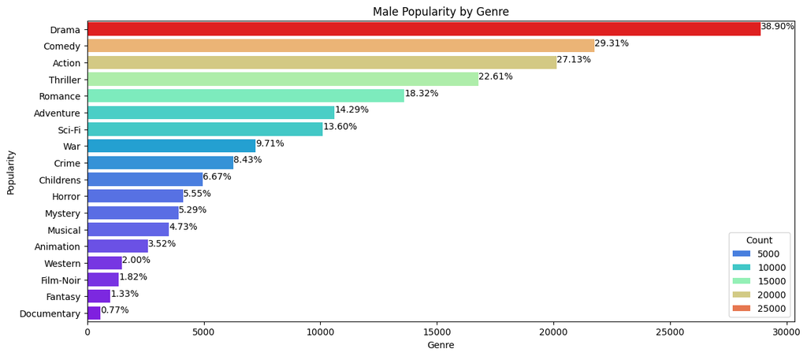

```python
plt.figure(figsize=(14, 6))

sns.barplot(y=MalePopularity.index, x='Count', data=MalePopularity, palette='rainbow', hue='Count')

for index, value in enumerate(MalePopularity['Count']):
    plt.text(value, index, f"{MalePopularity['Percentage'].iloc[index]:.2f}%")

plt.title('Male Popularity by Genre')
plt.xlabel('Genre')
plt.ylabel('Popularity')
plt.show()
```

#### Conclusion:

```python
# Combine the DataFrames
CombinedPopularity = pd.merge(FemalePopularity, MalePopularity, left_index=True, right_index=True, suffixes=('_Female', '_Male'))
CombinedPopularity = CombinedPopularity.reset_index().rename(columns={'index': 'Genre'})
CombinedPopularity.head()
```

|  | Genre | Count_Female | Percentage_Female | Count_Male | Percentage_Male |
| --- | --- | --- | --- | --- | --- |
| 0 | Drama | 11008 | 42.769446 | 28887 | 38.904003 |
| 1 | Comedy | 8068 | 31.346647 | 21764 | 29.310995 |
| 2 | Romance | 5858 | 22.760121 | 13603 | 18.320045 |
| 3 | Action | 5442 | 21.143834 | 20147 | 27.133276 |
| 4 | Thriller | 5086 | 19.760665 | 16786 | 22.606798 |

```python
# Melt the combined DataFrame for easier plotting
PlotData = CombinedPopularity.melt(id_vars='Genre', value_vars=['Percentage_Female', 'Percentage_Male'], var_name='Gender', value_name='Percentage')
# Map 'Count_Male' and 'Count_Female' to more readable labels
PlotData['Gender'] = PlotData['Gender'].map({'Percentage_Male': 'Male', 'Percentage_Female': 'Female'})

PlotData.head()
```

|  | Genre | Gender | Percentage |
| --- | --- | --- | --- |
| 0 | Drama | Female | 42.769446 |
| 1 | Comedy | Female | 31.346647 |
| 2 | Romance | Female | 22.760121 |
| 3 | Action | Female | 21.143834 |
| 4 | Thriller | Female | 19.760665 |

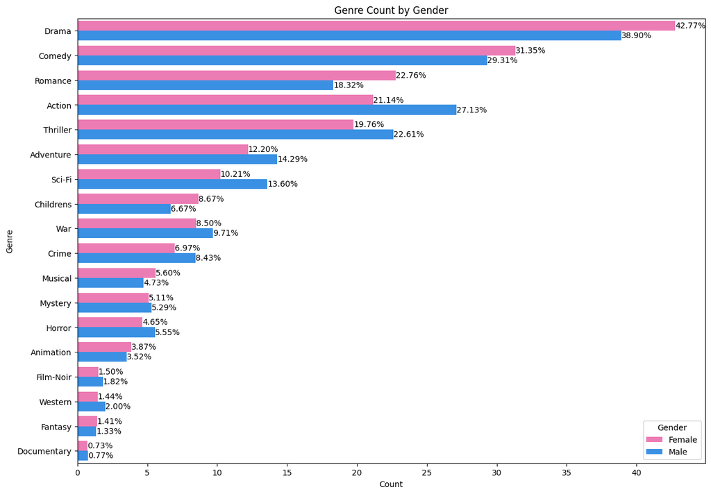

```python
plt.figure(figsize=(14, 10))

# Create the bar plot
sns.barplot(x='Percentage', y='Genre', hue='Gender', data=PlotData, palette={'Male': 'dodgerblue', 'Female': 'hotpink'})

for container in plt.gca().containers:
    plt.gca().bar_label(container, fmt='%.2f%%', label_type='edge')

# Add labels and title
plt.xlabel('Count')
plt.ylabel('Genre')
plt.title('Genre Count by Gender')

# Show the plot
plt.show()
```

- Men watch more drama than women => False
- Women watch more Sci-Fi than men => False
- Men watch more Romance than women => False